# Question 3:

What are the characteristics of subgroups of recidivists?

For this task, in order to discover the latent structure in our dataset, we use models from unsupervised learning.

Models: We focus here the 2 well-known clustering approaches, namely:

1. K-means Clustering
2. Hiearchical Clustering (Agglomerative)

Data Preparation:

1. The 4 target variables `Recidivism_Within_3years`,`Recidivism_Arrest_Year1`, `Recidivism_Arrest_Year2`, `Recidivism_Arrest_Year3` are dopped in this section.
2. Only the top 7 features identified in Question 1 are used here, namely 'Percent_Days_Employed','Jobs_Per_Year','Prior_Arrest_Episodes_PPViolationCharges','Age_at_Release', 'Gang_Affiliated','Supervision_Risk_Score_First','Prior_Arrest_Episodes_Felony', and unlike prediction task, we do not have to split the dataset into training and testing sets

Technically, we are using KMeans and AgglomerativeClustering from sklearn

## 3.1 K-means Clustering

```python
# picking k based on the discussion above
km_k8 = KMeans(random_state=0, n_clusters=8).fit(X)
km_k4 = KMeans(random_state=0, n_clusters=4).fit(X)
km_k3 = KMeans(random_state=0, n_clusters=3).fit(X)
```

[output not shown]

[output not shown]

### 3.3 Deep dive into k = 3 clusters formed with Kmeans

```python
print(f"Number and percentage of observations in cluster 1:", len(c1), 'and', round(len(c1)/ len(X)*100, 2), '%')
print("Number and percentage of observations in cluster 2:", len(c2), 'and',  round(len(c2)/ len(X)*100, 2), '%')
print("Number and percentage of observations in cluster 3:", len(c3), 'and',  round(len(c3)/len(X)*100, 2), '%')
```

```
Number and percentage of observations in cluster 1: 4283 and 31.21 %
Number and percentage of observations in cluster 2: 4795 and 34.94 %
Number and percentage of observations in cluster 3: 4644 and 33.84 %
```

### 3.4 Visualizing the clusters

#### 3.4.1 Boxplots

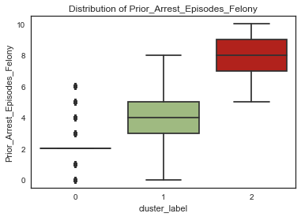

```python
# Prior_Arrest_Episodes_Felony
sns.boxplot(y="Prior_Arrest_Episodes_Felony", x="cluster_label", data=X_km_k3).set(title = "Distribution of Prior_Arrest_Episodes_Felony")

plt.show()
```

**Comments**

We can see from the boxplots that the distribution of Prior_Arrest_Episodes_Felony is very different in each cluster: cluster 0 has the lowest Prior_Arrest_Episodes_Felony, cluster 1 falls in the middle, while cluser 2 has highest number.

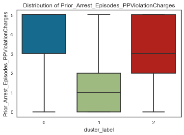

```python
# Prior_Arrest_Episodes_PPViolationCharges
sns.boxplot(y="Prior_Arrest_Episodes_PPViolationCharges", x="cluster_label", data=X_km_k3).set(title = "Distribution of Prior_Arrest_Episodes_PPViolationCharges")
plt.show()
```

**Comments**

We can see from the boxplots that the distribution of Prior_Arrest_Episodes_PPViolationCharges is quite different in each cluster.

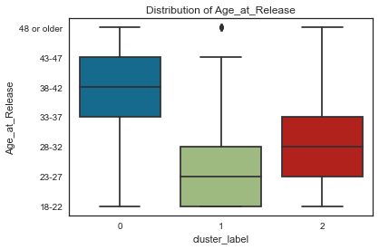

```python
# Age_at_Release
sns.boxplot(y="Age_at_Release", x="cluster_label", data=X_km_k3).set(title = "Distribution of Age_at_Release")
plt.yticks([0,1,2,3,4,5,6], ['18-22', '23-27', '28-32','33-37', '38-42', '43-47', '48 or older'])
plt.show()
```

**Comments**

Distribution of Age_at_Release are also different for each clusters

#### 3.4.2 Radar Plot

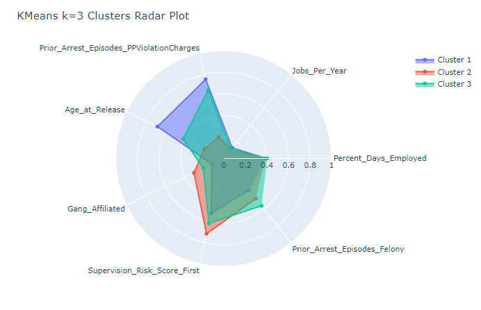

```python
Image(filename='radar.png')
```

## Answer to Q3:

We cluster our dataset into 3 groups using Kmeans clustering, among the models, we chose the k = 3 clusters for this purpose.

From the model, we can see that the cluster have different distribution in terms of Prior_Arrest_Episodes_Felony, Prior_Arrest_Episodes_PPViolationCharges, Age_at_Release, Gang_Affiliated.

# Future Work

Given extra time, we could search for extra datasets and information from the authority. With extra information, we could potentially reduce the existing irreducible error in our model and improve the accuracy.

1. **Extra data to be included:**
   - *Employment record of the individual*
     - Reason: from the feature importance in our models in question 1, they produced a consensus that suggests that Percent_Days Employed and Jobs_Per_Year are the most important features. We wish to further explore the types of jobs and potentially job security is an important factor affecting recidivism
   - *Financial Information of the individual*
     - Reason: an extension from the employment information, financial information, such as credit history, bankruptcy history, may suggest relationships with recidivism
- *Census data*
  - Public Use Microdata Areas (PUMA)
    - Reason: PUMA could be added to explore any relationship between recidivism and the community that the individual lives
  - *Georgia Department of Community Supervision*
    - Information regarding Community Supervision
      - Reason: to explore the effectiveness of community supervision and relationship
  - *Other information related to criminal history*
1. **Potential Improvements:**
   - *Question 1:* We tried to improve recall in our model as our primary goal is to ensure public safety, we could also explore the precision to improve the wrongful conviction cases.
   - *Question 2:* Since the implementation of scikit-learn's ROC curve is restricted to the binary classification task (see scikit-learn documentation), we shall explore the ROC AUC curve visualization for multiclass classification.
   - *Question 3:* Further explore dendrogram for hierarchical clustering.
2. **Other questions we could answer from the dataset:**
   - Is recidivism biased based on race?
   - Are the undereducated/underemployed population more susceptible to recidivism?
   - Community supervision
   - Other policy implications